# finalattempt1 - Amber Han (8689382) PSTAT 135

```python
!pip install --upgrade --force-reinstall scipy seaborn
```

```python
!pip install --upgrade gcsfs fsspec
```

```python
import pandas as pd
import matplotlib.pyplot as plt
import seaborn as sns

df = pd.read_csv("gs://bucketattempt1/notebooks/jupyter/ncr_ride_bookings.csv")
```

```python
!pip install --upgrade --force-reinstall scikit-learn
```

```python
from sklearn.model_selection import train_test_split
from sklearn.linear_model import LinearRegression
from sklearn.metrics import mean_absolute_error, r2_score
```

```python
!pip install --upgrade --force-reinstall numpy pyarrow scikit-learn
```

```python
from sklearn.linear_model import ElasticNet
from sklearn.neighbors import KNeighborsRegressor
from sklearn.preprocessing import StandardScaler
from sklearn.linear_model import LogisticRegression
from sklearn.discriminant_analysis import QuadraticDiscriminantAnalysis
from sklearn.neighbors import KNeighborsClassifier
from sklearn.metrics import accuracy_score
from sklearn.metrics import roc_auc_score, roc_curve
from sklearn.preprocessing import label_binarize
from sklearn.metrics import roc_curve, auc as auc_func
```

## Abstract

Car culture is a constant and immovable part of life while living in the United States of America. While efforts are continuously made to promote public transportation, the freeways are only getting bigger with more and more lanes that do not help with congestion at all. Bus stops and train stations are scarcely used for local transportation and people rely on more modern taxi services, namingly, Uber. The personalization of your pickup location is easier than ever with rideshare apps and Uber leads the charge.

## 1. Introduction

With this dataset, I became curious about the different conclusions I could make, such as what factors are relevant for high customer ratings, or what are the biggest factors for driver cancellation, what elements of the pickup and drop off location or time increase the price of a ride. As someone who tends to be wary of ridesharing alone and also obtaining a ride for as cheap as possible, optimizing the factors that will supply me with the most satisfying ride in ride completion, booking value, and driver ratings.

## 2. Data

This data set includes detailed ride-sharing data from Uber operations for the year 2024, capturing 148,770 total bookings across multiple vehicle types. I came across this dataset on Kaggle from the Kaggle user Yash dev Laddha (https://www.kaggle.com/datasets/yashdevladdha/uber-ride-analytics-dashboard). This dataset intrigued me with its most recent update being from 10 months ago, inspiring confidence in me for its currency. It is described that this dataset was collected from Uber operation's public ride-sharing data for the year of 2024.

Studying the data set lends itself to assisting Uber in making operation decisions that will minimize cancellations, improve wait times, and generally optimize a user's and driver's experience of riding with Uber. When inefficiencies in operation appear, it is potential for lost revenue for Uber, lost income for the driver, and a customer who is stranded and unable to go where they need to go. By eliminating inefficiencies, Uber can reduce cancellations of bookings, retain drivers, and create loyal customers that have the most satisfactory experience with Uber.

The author of the data notes that the key statistics highlighted in the data set are:

- Total Bookings: 148.77K rides
- Success Rate: 65.96% (93K completed rides)
- Cancellation Rate: 25% (37.43K cancelled bookings)
- Customer Cancellations: 19.15% (27K rides)
- Driver Cancellations: 7.45% (10.5K rides)

And these are only 5 out of 21 columns mentioned in the data set. This project primarily used Date, Time, Booking Status, Vehicle Type, Booking Value, Ride Distance, and Avg CTAT.

## 3. Methodology

This project utilizes supervised learning.

All classification models were evaluated using accuracy and multi-class ROC AUC. Features were standardized prior to fitting KNN and QDA. An 80/20 train-test split was used throughout, stratified by the target class to preserve class proportions.

## 4. Results:

### Reading in my data

[Uber Data Link](https://www.kaggle.com/datasets/yashdevladdha/uber-ride-analytics-dashboard?resource=download)

```python
df.head()
```

|  | Date | Time | Booking ID | Booking Status | Customer ID | Vehicle Type | Pickup Location | Drop Location | Avg VTAT | Avg CTAT | ... | Reason for cancelling by Customer | Cancelled Rides by Driver | Driver Cancellation Reason | Incomplete Rides | Incomplete Rides Reason | Booking Value | Ride Distance | Driver Ratings | Customer Rating | Payment Method |
| --- | --- | --- | --- | --- | --- | --- | --- | --- | --- | --- | --- | --- | --- | --- | --- | --- | --- | --- | --- | --- | --- |
| 0 | 2024-03-23 | 12:29:38 | "CNR5884300" | No Driver Found | "CID1982111" | eBike | Palam Vihar | Jhilmil | NaN | NaN | ... | NaN | NaN | NaN | NaN | NaN | NaN | NaN | NaN | NaN | NaN |
| 1 | 2024-11-29 | 18:01:39 | "CNR1326809" | Incomplete | "CID4604802" | Go Sedan | Shastri Nagar | Gurgaon Sector 56 | 4.9 | 14.0 | ... | NaN | NaN | NaN | 1.0 | Vehicle Breakdown | 237.0 | 5.73 | NaN | NaN | UPI |
| 2 | 2024-08-23 | 08:56:10 | "CNR8494506" | Completed | "CID9202816" | Auto | Khandsa | Malviya Nagar | 13.4 | 25.8 | ... | NaN | NaN | NaN | NaN | NaN | 627.0 | 13.58 | 4.9 | 4.9 | Debit Card |
| 3 | 2024-10-21 | 17:17:25 | "CNR8906825" | Completed | "CID2610914" | Premier Sedan | Central Secretariat | Inderlok | 13.1 | 28.5 | ... | NaN | NaN | NaN | NaN | NaN | 416.0 | 34.02 | 4.6 | 5.0 | UPI |
| 4 | 2024-09-16 | 22:08:00 | "CNR1950162" | Completed | "CID9933542" | Bike | Ghitorni Village | Khan Market | 5.3 | 19.6 | ... | NaN | NaN | NaN | NaN | NaN | 737.0 | 48.21 | 4.1 | 4.3 | UPI |

5 rows × 21 columns

It appears the Date and Time columns are stored separately, which is not conducive for analysis. I will extract the Date and Time column, combine them into one, and then add them back to the data frame. This is in order to determine what ride times generate the most revenue.

```python
df['datetime'] = pd.to_datetime(df['Date'] + ' ' + df['Time'])
```

```python
dfnew = df.drop(columns=['Date', 'Time'])

# Checking if the columns Date and Time were dropped and datetime is successfully added

dfnew.head()
```

|  | Booking ID | Booking Status | Customer ID | Vehicle Type | Pickup Location | Drop Location | Avg VTAT | Avg CTAT | Cancelled Rides by Customer | Reason for cancelling by Customer | Cancelled Rides by Driver | Driver Cancellation Reason | Incomplete Rides | Incomplete Rides Reason | Booking Value | Ride Distance | Driver Ratings | Customer Rating | Payment Method | datetime |
| --- | --- | --- | --- | --- | --- | --- | --- | --- | --- | --- | --- | --- | --- | --- | --- | --- | --- | --- | --- | --- |
| 0 | "CNR5884300" | No Driver Found | "CID1982111" | eBike | Palam Vihar | Jhilmil | NaN | NaN | NaN | NaN | NaN | NaN | NaN | NaN | NaN | NaN | NaN | NaN | NaN | 2024-03-23 12:29:38 |
| 1 | "CNR1326809" | Incomplete | "CID4604802" | Go Sedan | Shastri Nagar | Gurgaon Sector 56 | 4.9 | 14.0 | NaN | NaN | NaN | NaN | 1.0 | Vehicle Breakdown | 237.0 | 5.73 | NaN | NaN | UPI | 2024-11-29 18:01:39 |
| 2 | "CNR8494506" | Completed | "CID9202816" | Auto | Khandsa | Malviya Nagar | 13.4 | 25.8 | NaN | NaN | NaN | NaN | NaN | NaN | 627.0 | 13.58 | 4.9 | 4.9 | Debit Card | 2024-08-23 08:56:10 |
| 3 | "CNR8906825" | Completed | "CID2610914" | Premier Sedan | Central Secretariat | Inderlok | 13.1 | 28.5 | NaN | NaN | NaN | NaN | NaN | NaN | 416.0 | 34.02 | 4.6 | 5.0 | UPI | 2024-10-21 17:17:25 |
| 4 | "CNR1950162" | Completed | "CID9933542" | Bike | Ghitorni Village | Khan Market | 5.3 | 19.6 | NaN | NaN | NaN | NaN | NaN | NaN | 737.0 | 48.21 | 4.1 | 4.3 | UPI | 2024-09-16 22:08:00 |

Currently, the Booking.ID and Customer.ID columns include quotations in their values. I will remove them for consistency with the rest of the data values.

```python
dfnew['Booking ID'] = dfnew['Booking ID'].str.replace('"', '')
dfnew['Customer ID'] = dfnew['Customer ID'].str.replace('"', '')

# Checking if columns Booking ID and Customer ID successfully had their quotations removed

dfnew.head()
```

|  | Booking ID | Booking Status | Customer ID | Vehicle Type | Pickup Location | Drop Location | Avg VTAT | Avg CTAT | Cancelled Rides by Customer | Reason for cancelling by Customer | Cancelled Rides by Driver | Driver Cancellation Reason | Incomplete Rides | Incomplete Rides Reason | Booking Value | Ride Distance | Driver Ratings | Customer Rating | Payment Method | datetime |
| --- | --- | --- | --- | --- | --- | --- | --- | --- | --- | --- | --- | --- | --- | --- | --- | --- | --- | --- | --- | --- |
| 0 | CNR5884300 | No Driver Found | CID1982111 | eBike | Palam Vihar | Jhilmil | NaN | NaN | NaN | NaN | NaN | NaN | NaN | NaN | NaN | NaN | NaN | NaN | NaN | 2024-03-23 12:29:38 |
| 1 | CNR1326809 | Incomplete | CID4604802 | Go Sedan | Shastri Nagar | Gurgaon Sector 56 | 4.9 | 14.0 | NaN | NaN | NaN | NaN | 1.0 | Vehicle Breakdown | 237.0 | 5.73 | NaN | NaN | UPI | 2024-11-29 18:01:39 |
| 2 | CNR8494506 | Completed | CID9202816 | Auto | Khandsa | Malviya Nagar | 13.4 | 25.8 | NaN | NaN | NaN | NaN | NaN | NaN | 627.0 | 13.58 | 4.9 | 4.9 | Debit Card | 2024-08-23 08:56:10 |
| 3 | CNR8906825 | Completed | CID2610914 | Premier Sedan | Central Secretariat | Inderlok | 13.1 | 28.5 | NaN | NaN | NaN | NaN | NaN | NaN | 416.0 | 34.02 | 4.6 | 5.0 | UPI | 2024-10-21 17:17:25 |
| 4 | CNR1950162 | Completed | CID9933542 | Bike | Ghitorni Village | Khan Market | 5.3 | 19.6 | NaN | NaN | NaN | NaN | NaN | NaN | 737.0 | 48.21 | 4.1 | 4.3 | UPI | 2024-09-16 22:08:00 |

Successful!

Now if I want to analyze revenue, I should focus on the columns that impact revenue and which rides generate revenue. This means I should look towards the completed rides and disregard the incomplete rides.

```python
completed = dfnew[dfnew['Booking Status'] == 'Completed'].copy()

# Checking if dataframe was filtered successfully

completed.head()
```

|  | Booking ID | Booking Status | Customer ID | Vehicle Type | Pickup Location | Drop Location | Avg VTAT | Avg CTAT | Cancelled Rides by Customer | Reason for cancelling by Customer | Cancelled Rides by Driver | Driver Cancellation Reason | Incomplete Rides | Incomplete Rides Reason | Booking Value | Ride Distance | Driver Ratings | Customer Rating | Payment Method | datetime |
| --- | --- | --- | --- | --- | --- | --- | --- | --- | --- | --- | --- | --- | --- | --- | --- | --- | --- | --- | --- | --- |
| 2 | CNR8494506 | Completed | CID9202816 | Auto | Khandsa | Malviya Nagar | 13.4 | 25.8 | NaN | NaN | NaN | NaN | NaN | NaN | 627.0 | 13.58 | 4.9 | 4.9 | Debit Card | 2024-08-23 08:56:10 |
| 3 | CNR8906825 | Completed | CID2610914 | Premier Sedan | Central Secretariat | Inderlok | 13.1 | 28.5 | NaN | NaN | NaN | NaN | NaN | NaN | 416.0 | 34.02 | 4.6 | 5.0 | UPI | 2024-10-21 17:17:25 |
| 4 | CNR1950162 | Completed | CID9933542 | Bike | Ghitorni Village | Khan Market | 5.3 | 19.6 | NaN | NaN | NaN | NaN | NaN | NaN | 737.0 | 48.21 | 4.1 | 4.3 | UPI | 2024-09-16 22:08:00 |
| 5 | CNR4096693 | Completed | CID4670564 | Auto | AIIMS | Narsinghpur | 5.1 | 18.1 | NaN | NaN | NaN | NaN | NaN | NaN | 316.0 | 4.85 | 4.1 | 4.6 | UPI | 2024-02-06 09:44:56 |
| 6 | CNR2002539 | Completed | CID6800553 | Go Mini | Vaishali | Punjabi Bagh | 7.1 | 20.4 | NaN | NaN | NaN | NaN | NaN | NaN | 640.0 | 41.24 | 4.0 | 4.1 | UPI | 2024-06-17 15:45:58 |

I've successfully filtered the rides to only include completed rides.

The following will be some exploratory data analysis to discover what are the most influential factors towards Booking Value.

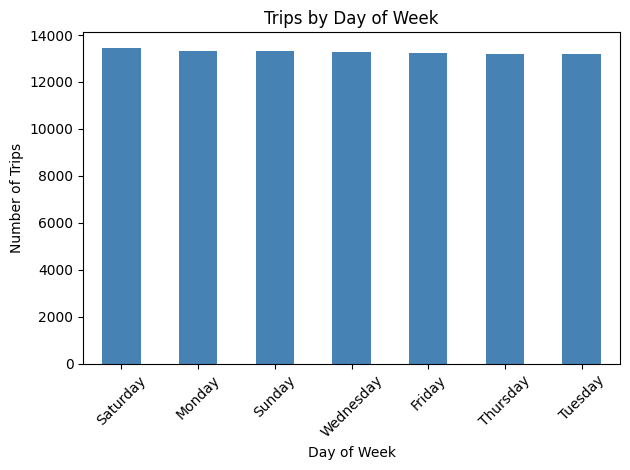

```python
# Trips per day of the week

completed['day_of_week'] = completed['datetime'].dt.day_name()
daily_counts = completed['day_of_week'].value_counts()

daily_counts.plot(kind='bar', color='steelblue')
plt.title('Trips by Day of Week')
plt.xlabel('Day of Week')
plt.ylabel('Number of Trips')
plt.xticks(rotation=45)
plt.tight_layout()
plt.show()
```

It seems that the day of the week does not have much bearing on the amount of trips made in a day. No day has a significantly greater trip amount than another.

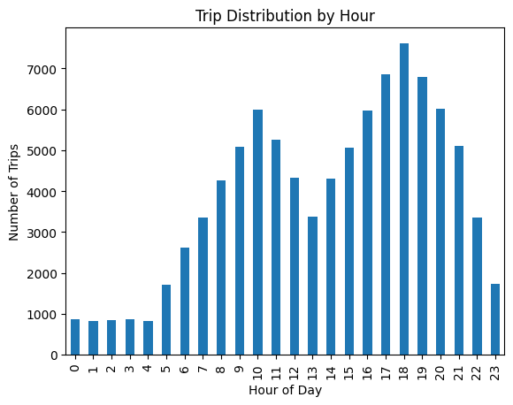

```python
# Trips per hour

completed['pickup_hour'] = completed['datetime'].dt.hour
hourly_counts = completed['pickup_hour'].value_counts().sort_index()
hourly_counts.plot(kind='bar', title='Trip Distribution by Hour')
plt.xlabel('Hour of Day')
plt.ylabel('Number of Trips')
plt.show()
```

There is a clear difference in hours on how many trips are completed at different times of day. To further emphasize this, I created a heatmap.

```python
# Making a heatmap to display both the hour and day together at once

heatmap_data = completed.groupby(['day_of_week', 'pickup_hour']).size().unstack(fill_value=0)

day_order = ['Monday','Tuesday','Wednesday','Thursday','Friday','Saturday','Sunday']
heatmap_data = heatmap_data.reindex(day_order)
```

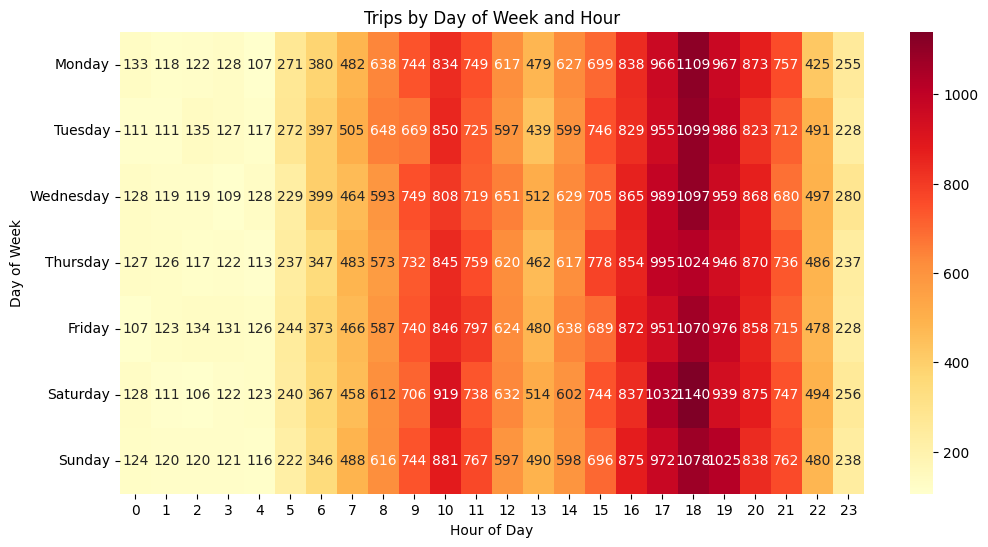

```python
plt.figure(figsize=(12, 6))
sns.heatmap(heatmap_data, cmap='YlOrRd', annot=True, fmt='d')
plt.title('Trips by Day of Week and Hour')
plt.xlabel('Hour of Day')
plt.ylabel('Day of Week')
plt.show()
```

There is an apparent popular time to order an Uber that causes the amount of trips made to increase greatly. The hours of day, every day, that apparently have the most trips made are around hour 10 and hour 18. This leads me to believe that there is surge pricing or an effect on the booking price around these time slots. This affirms the first exploration of trips by hour of the day.

Furthermore, I am also curious about whether passenger size has any effect on the pricing of Uber rides. Let me calculate average booking price by vehicle type.

```python
# Calculating average booking price by vehicle type

completed = df[df['Booking Status'] == 'Completed'].copy()
result = completed.groupby('Vehicle Type')['Booking Value'].agg(['mean', 'count'])
print(result)
```

```
                     mean  count
Vehicle Type
Auto           506.483049  23155
Bike           509.114508  14034
Go Mini        507.381422  18549
Go Sedan       512.026865  16676
Premier Sedan  509.567632  11252
Uber XL        505.302192   2783
eBike          503.458556   6551
```

Under the mean column is the mean price at booking and the count is the total completed rides with that vehicle type. The price differences betweeen all vehicles are not that large which indicates to me that the vehicle type has little to no bearing on the booking value and does not serve much if I am trying to find out what will affect the prices of booking with Uber.

Next, I want to examine whether AVG CTAT, or average travel time, has an impace on booking prices.

```python
# Calculating average booking price by length of time of the ride

completed2 = completed.dropna(subset=['Avg CTAT','Booking Value'])

bins = [0,300,400,500,600,700,800,1000,2000]
completed2['fare_bin'] = pd.cut(completed2['Booking Value'], bins=bins)
ctatresult = completed2.groupby('fare_bin')['Avg CTAT'].agg(['mean','count'])
print(ctatresult)
```

```
                   mean  count
fare_bin
(0, 300]      29.992887  31732
(300, 400]    29.936459  13042
(400, 500]    30.201336  12651
(500, 600]    30.140226   6712
(600, 700]    30.116293   6328
(700, 800]    29.904115   5614
(800, 1000]   30.038855   9623
(1000, 2000]  30.024431   6410
```

The fare_bin column indicates ranges of prices, the mean column is the average travel time, and the count column is the amount of rides that fall in the the indicated price range and travel time. Across the different prices and travel times, the differences are again more miniscule. As the price range increases, there is a similar average travel time across all prices which leads me to believe that the travel time has no large influence on price. The price of a ride does not heavily depend on travel time, such as a shorter travel time will not necessarily have a cheaper booking price.

```python
# Calculating the average booking price by distance of the ride

completed3 = completed.dropna(subset=['Ride Distance','Booking Value'])

bins = [0,2,4,6,8,10,15,20,30,50]
completed3['distance_bin'] = pd.cut(completed3['Ride Distance'], bins=bins)
distresult = completed3.groupby('distance_bin')['Booking Value'].agg(['mean','count'])
print(distresult)
```

```
                    mean  count
distance_bin
(0, 2]        572.500000      8
(2, 4]        501.936745   3810
(4, 6]        506.344633   3894
(6, 8]        500.010209   3918
(8, 10]       504.927067   3894
(10, 15]      502.840348   9527
(15, 20]      510.293304   9693
(20, 30]      511.949405  19508
(30, 50]      509.000232  38748
```

The distance_bin represents the varying ranges of distances in a ride, the mean column represents the average booking price within the rides that are of that distance range. There is a bit more varying average price in between ride distances with the entry of a mean price of 572.500000, but that only has 8 rides to make of it and cannot be properly compared to the other entries with over 3.8k rides. Looking at all other entries and distances, the average booking price remains close to each other with a small difference across all distance ranges. This similarly indicates that ride distance has little influence on booking price.

```python
# Calculating the average booking price by hour of the day

completed3 = completed.dropna(subset=['Time','Booking Value'])

completed3['hour'] = pd.to_datetime(completed3['Time'], format='%H:%M:%S').dt.hour
hourresult = completed3.groupby('hour')['Booking Value'].agg(['mean','count'])
print(hourresult)
```

```
            mean  count
hour
0     507.841492    858
1     514.411836    828
2     509.672919    853
3     504.317442    860
4     503.914458    830
5     499.312536   1715
6     515.489460   2609
7     500.841602   3346
8     511.776189   4267
9     517.559205   5084
10    511.078389   5983
11    502.062809   5254
12    514.472568   4338
13    498.949348   3376
14    500.418097   4310
15    507.083646   5057
16    504.558291   5970
17    513.468513   6860
18    513.084810   7617
19    499.531921   6798
20    505.473605   6005
21    513.875710   5109
22    505.411221   3351
23    519.260743   1722
```

There is a bit more range of pricing with the different hours of the day, from 498 to 519, but it still is not that significant. Across different hours, I cannot say there is a large influence on pricing or any surge pricing that occurs based on the time of day. Based on everything, it appears booking value is more randomly distributed than anything.

```python
# Keeping only Ride Distance and Booking Value, dropping missing values

completed4 = completed.dropna(subset=['Ride Distance','Booking Value','Vehicle Type'])

# Making X a predictor equal to distance, and y is the target equal to fare

X = completed4[['Ride Distance','Booking Value']]
y = completed4['Vehicle Type']

X_train, X_test, y_train, y_test = train_test_split(X, y, test_size=0.2, random_state=42, stratify=y)

scaler = StandardScaler()
X_train_s = scaler.fit_transform(X_train)
X_test_s = scaler.transform(X_test)

log_reg = LogisticRegression(max_iter=1000)
log_reg.fit(X_train_s, y_train)
print("Logistic:", accuracy_score(y_test, log_reg.predict(X_test_s)))

qda = QuadraticDiscriminantAnalysis()
qda.fit(X_train_s, y_train)
print("QDA:", accuracy_score(y_test, qda.predict(X_test_s)))

knn = KNeighborsClassifier(n_neighbors=5)
knn.fit(X_train_s, y_train)
print("KNN:", accuracy_score(y_test, knn.predict(X_test_s)))

print("Baseline:", y.value_counts(normalize=True).max())
```

```
Logistic: 0.24897849462365593
QDA: 0.24876344086021504
KNN: 0.20102150537634408
Baseline: 0.24897849462365593
```

Logistic regression, quadratic discriminant analysis (QDA), and K-Nearest Neighbors (KNN) is used to test whether vehicle type could be classified from ride distance and booking value

According to these results, logistic regression correctly predicted Vehicle Type for only ~25% of test rides. QDA predicted similarly at 0.249, ~25% and practically identical. KNN did worse, at only ~20% correct. The baseline is 0.249, ~25%. So if someone always guessed the most common vehicle type, which would be Auto, they'd be right ~25% of the time.

Since logistic and QDA match the baseline exactly, they're essentially not learning anything beyond just guessing the majority class. KNN performs worse than guessing the majority class, meaning it's actively misled by the features. It appears none of these models can predict vehicle type from Ride Distance and Booking Value, which is consistent with my current findings that the dataset's fields don't have meaningful relationships with each other.

[figure not shown]

```python
# Removes rows where Ride Distance or Booking Value is missing

completed5 = completed.dropna(subset=['Ride Distance','Booking Value'])

fig, axes = plt.subplots(1, 2, figsize=(12,5))

axes[0].scatter(completed['Ride Distance'], completed5['Booking Value'], alpha=0.1, s=5)
axes[0].set_xlabel('Ride Distance (km)')
axes[0].set_ylabel('Booking Value')
axes[0].set_title('Fare vs Distance (corr ≈ 0.006)')

completed5.boxplot(column='Booking Value', by='Vehicle Type', ax=axes[1], rot=45)
axes[1].set_title('Fare Distribution by Vehicle Type')
plt.suptitle('')

plt.tight_layout()
plt.show()
```

In the plot on the left, the scatter plot, the points are densely packed across all distances from 0 to 50. The rest of the points show a uniform scatter across all distances from 0 to 4000, forming a vague "cloud" and not demonstrating any sort of trend or relationship. If distance were a factor in price, then there should be some sort of trend upward or downwards as the distance increases or decreases.

The boxplot on the right shows nearly identical fare distributions across all vehicle types. There lies the same median, same interquartile range, and same outlier pattern. This affirms the earlier distinction that vehicle type does not meaningfully affect the booking price of a ride.

```python
# Keeping only rows where Booking Status is "Completed", "Cancelled by Driver", or "Cancelled by Customer"
df_model = df[df['Booking Status'].isin(['Completed','Cancelled by Driver','Cancelled by Customer'])].copy()

# Creating binary target. cancelled = 1 if status is anything other than "Completed", else 0.
df_model['cancelled'] = (df_model['Booking Status'] != 'Completed').astype(int)

# Extract hour
df_model['hour'] = pd.to_datetime(df_model['Time'], format='%H:%M:%S').dt.hour

# Extract day of week
df_model['day_of_week'] = pd.to_datetime(df_model['Date']).dt.dayofweek

# Converting the categorical Vehicle Type column into multiple binary 0/1 columns
df_model = pd.get_dummies(df_model, columns=['Vehicle Type'], drop_first=True)

feature_cols = ['hour','day_of_week'] + [c for c in df_model.columns if c.startswith('Vehicle Type_')]
X = df_model[feature_cols]
y = df_model['cancelled']

X_train, X_test, y_train, y_test = train_test_split(X, y, test_size=0.2, random_state=42, stratify=y)
scaler = StandardScaler()
X_train_s = scaler.fit_transform(X_train)
X_test_s = scaler.transform(X_test)
```

```python
# Splitting Booking Value into 3 equal-sized groups based on value ranges
completed['fare_class'] = pd.qcut(completed['Booking Value'], q=3, labels=['low','mid','high'])

completed['hour'] = pd.to_datetime(completed['Time'], format='%H:%M:%S').dt.hour
completed = pd.get_dummies(completed, columns=['Vehicle Type'], drop_first=True)
feature_cols = ['Ride Distance','Avg CTAT','hour'] + [c for c in completed.columns if c.startswith('Vehicle Type_')]

X2 = completed[feature_cols]
y2 = completed['fare_class']

X_train, X_test, y_train, y_test = train_test_split(X2, y2, test_size=0.2, random_state=42, stratify=y2)

# Standardizing features
scaler = StandardScaler()
X_train_s = scaler.fit_transform(X_train)
X_test_s = scaler.transform(X_test)

# Looping through models
for name, model in models.items():
    model.fit(X_train_s, y_train)
    probs = model.predict_proba(X_test_s)
    auc2 = roc_auc_score(y_test, probs, multi_class='ovr')
    print(f"{name}: {auc2:.4f}")
```

```
Logistic Regression: 0.5009
QDA: 0.5008
KNN: 0.5014
```

All three models score essentially 0.50, which is the AUC value for pure random guessing.

Again, this means none of the models can distinguish between low, mid, and high fare rides any better than someone guessing blindly, while using Ride Distance, Avg CTAT, hour, and Vehicle Type as predictors. Even though there are tiny differences, this is interpreted as noise and are not meaningfully different from each other. This is consistent with everything else I've found where the booking price appears to be assigned independently of these trip characteristics in this dataset.

Now I want to verify the validity of the models by using ROC AUC. If I were to compare the performances of the models using ROC AUC, the model with the highest ROC AUC will have performed the best.

[figure not shown]

```python
y_test_bin = label_binarize(y_test, classes=['low','mid','high'])

fig, axes = plt.subplots(1, 3, figsize=(15,5))

for ax, (name, model) in zip(axes, models.items()):
    model.fit(X_train_s, y_train)
    probs = model.predict_proba(X_test_s)
    for i, cls in enumerate(['low','mid','high']):
        fpr, tpr, _ = roc_curve(y_test_bin[:,i], probs[:,i])
        roc_auc2 = auc_func(fpr, tpr)
        ax.plot(fpr, tpr, label=f"{cls} (AUC={roc_auc2:.3f})")
    ax.plot([0,1],[0,1],'k--', label='Random')
    ax.set_title(name)
    ax.set_xlabel('False Positive Rate')
    ax.set_ylabel('True Positive Rate')
    ax.legend(fontsize=8)

plt.suptitle('Multi-class ROC: Predicting Fare Class (Low/Mid/High)')
plt.tight_layout()
plt.show()
```

As you can see, the Logistic Regression, QDA, and KNN models all produce ROC curves representing the range of price for booking an Uber that lie almost entirely on top of the diagonal line, the "Random" line. There are AUC values clustered tightly around 0.50. This means that none of the models can confidently distinguish between a low price, mid price, or high price Uber ride better than a random guess while using the features of Ride Distance, Avg CTAT, hour of the day, or vehicle type to aid in its prediction ability. There is a slight variation in QDA's curve than the other models and their lines, but it does not represent anything meaningful.

To attempt to predict the price class (low, mid, or high) of an Uber ride upon booking using my current trip characteristics is not so successful regardless of the different model types.

## Conclusion and Future Study

While this outcome differs from what real-world rideshare pricing studies typically find, where distance, duration, and surge pricing are major fare drivers, the analysis did reveal a clear, consistent pattern in trip volume: ride requests peak around 10 AM and 6 PM, aligning with typical commute times, while volume by day of week showed comparatively little variation. This suggests that demand fluctuates predictably with time of day even though, in this dataset, price does not.

These findings suggest that Booking Value in this dataset may be synthetically generated independent of other trip fields, rather than reflecting a realistic pricing model tied to distance, demand, or vehicle type.

Future study could take several directions. First, applying this same methodology to a dataset with verified real-world pricing logic would serve as a useful comparison, to confirm that the modeling approach itself is sound and would detect a genuine distance-price relationship if one existed. If an updated or alternative version of this dataset becomes available with verified pricing logic, revisiting the regression and classification models on Booking Value would be worthwhile to see whether the same null results hold.

## References

Yash Dev Laddha. "Uber Data Analytics Dashboard." Kaggle, 2025. https://www.kaggle.com/datasets/yashdevladdha/uber-ride-analytics-dashboard?resource=download

## AI Attribution

AI was used in assistance of this project in the form of grammar checking and keeping my writing style consistent and accurate in the description of the actual work done in the code. I also used it to seek feedback on my draft and took its suggested revisions to increase the impact of my report in my own narrative style.